# IODS course project

Jukke Kaaronen

# Introduction to Open Data Science - Course Project

# Chapter 1

Introduction to Open Data Science [My GitHub Repository](https://github.com/jukkekaaronen/IODS-project)

```r
# This is a so-called "R chunk" where you can write R code.

date()
```

```
## [1] "Thu Dec 03 22:07:32 2020"
```

## Day 1

**Feeling:** After downloading and installing the latest version of R and Git (what Git *really is*, is still a bit of a mystery to me) I proceeded to complete the DataCamp excercises and earn a jaw-dropping mouth-watering **1870 XP** and a fancy certificate delivered straight to my e–mail along with some spam offers from the team at DataCamp. I feel great and excited about the course!

**Expectations:** I work on the analysis of impoliteness and negative evaluation in fictional texts and have previously been using RStudio and simple R-scripts to explore my results. From this course I hope to learn new skills for using R and RStudio for future research, get acquainted with the workings of GitHub, increase my understanding of data science and statistics (coming from a qualitative field of research), and increase the quality of my research and the way I plan, collect and analyse my datasets.

# Chapter 2 Regression and Model Validation

*This week I have worked on wrangling and analysing a dataset for learning approaches. I have learned how to do linear model analysis in R and produce visualizations of the results. For me, The trickiest part of this weeks exercise was understanding how to interpret the statistical tests and diagnostic plots and what they mean*

```r
date()
```

```
## [1] "Thu Dec 03 22:07:32 2020"
```

## 1

## 1.1 Reading the Dataset and Calling Packages

Packages required for this report include the dplyr, ggplot2, GGally and kableExtra packages. The packages are called with `library`.  
The dataset is in .csv format in the local directory and is read with the `read.csv` function and assigned a value (**l14**) below. For some reason the .csv is mutated with a column for row number. I leave it out by selecting the 7 variables with a `%>%` pipe operator.

```r
###library dplyr###

library(dplyr)
library(GGally)
```

```r
library(ggplot2)
library(kableExtra)
#read dataset from local directory

l14 <- read.csv("C:/Users/Jukke/OneDrive/Työpöytä/IODS/IODS-project/data/ln14_analysis.csv") %>% select(gender, Age, attitude, deep, stra, surf, Points)
```

## 1.2 Description of the Dataset

The **l14** dataset is derived from data collected by Vehkalahti (Dec 2014 - Jan 2015) ) from a questionnaire for Finnish students about their learning habits and approaches. The questionnaire includes a brief 32 item version of the ASSIST (Approaches and Study Skills Inventory for Students) as well as a SATS (Survey of Attitudes towards Statistics) ([link to meta documentation](https://www.mv.helsinki.fi/home/kvehkala/JYTmooc/JYTOPKYS3-meta.txt), accessed Nov 3rd 2020). Questions were answered on a scale of 1-5.  
The **l14** dataset consists of means counted for each respondent from clusters of questions related to the variables of attitude (10 items), deep learning (12 items), surface learning (12 items) and strategic learning (10 items) ([see here](https://www.mv.helsinki.fi/home/kvehkala/JYTmooc/JYTOPKYS2-meta.txt), accessed Nov 3 2020).  
Deep learning refers to student’s intention to maximize understanding. Surface learning refers to memorizing without understanding. Strategic learning refers to applying strategies that maximize possibilities for highest grades.

## 2

## 2.1 Graphical Overview

A graphical overview in Figure 1 displays the **l14** dataset and its 7 variables (gender, age, attitude, deep learning, strategic learning, surface learning and exam points) in relation to each other.  
The figure is produced with the `ggpairs` function from the GGally package.

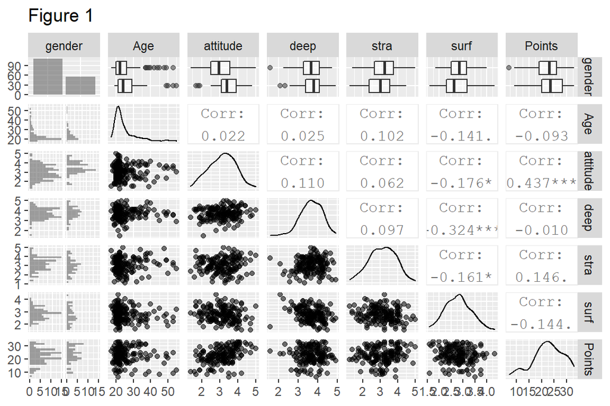

```r
p <- ggpairs(l14, mapping = aes(alpha = 0.3), lower = list(combo = wrap("facethist", bins = 20))) + ggtitle("Figure 1")

# draw the plot
p
```

From this overview we can find a correlation between attitude and exam points (0.437), as well as negative correlation between attitude and surface learning (memorizing without understanding) (-0.176) and a negative correlation between surface learning and deep learning (-0.324). These seem fairly intuitive as students might be expected to score systematically differently on deep and surface learning, and we might expect attitudes towards statistics to correlate with students’ exam points.

## 2.2 Variables

This section discusses the variables by exploring the dataset with the `summary` function and a `count` of gender. The summary shows the minimum and maximum values appearing in the dataset for each variable as well as their mean and median values.

```r
l14_sum <- summary(l14[-1])
print(l14_sum)
```

```
##       Age           attitude          deep            stra
##  Min.   :17.00   Min.   :1.400   Min.   :1.583   Min.   :1.250
##  1st Qu.:21.00   1st Qu.:2.600   1st Qu.:3.333   1st Qu.:2.625
##  Median :22.00   Median :3.200   Median :3.667   Median :3.188
##  Mean   :25.51   Mean   :3.143   Mean   :3.680   Mean   :3.121
##  3rd Qu.:27.00   3rd Qu.:3.700   3rd Qu.:4.083   3rd Qu.:3.625
##  Max.   :55.00   Max.   :5.000   Max.   :4.917   Max.   :5.000
##       surf           Points
##  Min.   :1.583   Min.   : 7.00
##  1st Qu.:2.417   1st Qu.:19.00
##  Median :2.833   Median :23.00
##  Mean   :2.787   Mean   :22.72
##  3rd Qu.:3.167   3rd Qu.:27.75
##  Max.   :4.333   Max.   :33.00
```

```r
l14_gen <- count(l14, gender)

kable(l14_gen, format = "html", caption = " Table 1 Students' Gender")
```

Table 1 Students’ Gender

| gender | n |
| --- | --- |
| F | 110 |
| M | 56 |

**Age**: Respondents are aged between 17 and 55 with the median age being 22.  
**Gender**: Male/Female with 56M and 110F  
**Learning approaches**: Deep, surface and strategic learning approaches and their min-max values occurring in the dataset (scored by means discussed in previous section)  
**Attitude**: Students’ attitude score and min-max values occurring in the dataset  
**Points**: Exam points with a range of 7-33 and a mean of 22.72

## 3

## 3.1 Selecting Explanatory Variables

This section will investigate the relation between the students’ exam points (target value) and their deep and surface learning approaches as well as their attitude. The objective is to find out if the explanatory variables (**attitude**, **surface learning**, **deep learning**) are associated in a systematic way to students’ exam points. First, lets look at the explanatory variables in relation to exam points individually in scatter plots:

### 3.1.1 Attitude and Exam Points

These scatter plots are produced with `ggplot2` by mapping the exploratory variables on the x axis with exam points on the y axis, and separated by gender with the `col = gender` value. The `geom_point` creates points for each location in the dataset. The `geom_smooth(method = "lm")` creates the linear regression model line. In section 3.2 these relations are explored further with multiple linear regression.

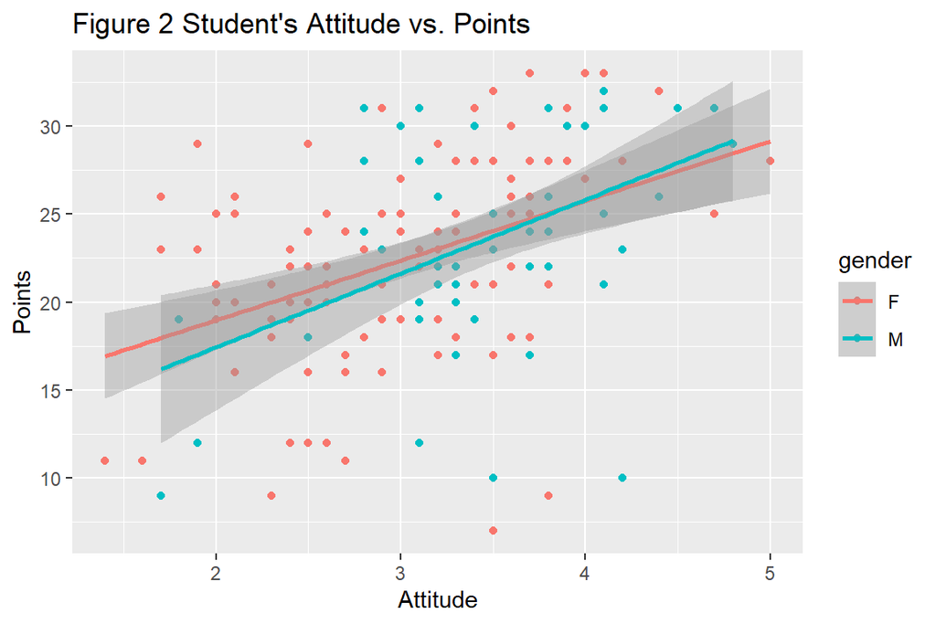

```r
plot_ap <- ggplot(l14, aes(x = attitude, y = Points, col = gender)) + geom_point() + geom_smooth(method = "lm") + ggtitle("Figure 2 Student's Attitude vs. Points") + labs(x = "Attitude")
plot_ap
```

Figure 2 shows that Attitude and Exam points seem to have some linear regression. The same can not be said for the deep learning and surface learning approaches (Figures 3 and 4) which do not show evidence towards significant linear regression:

### 3.1.2 Deep Learning and Exam Points

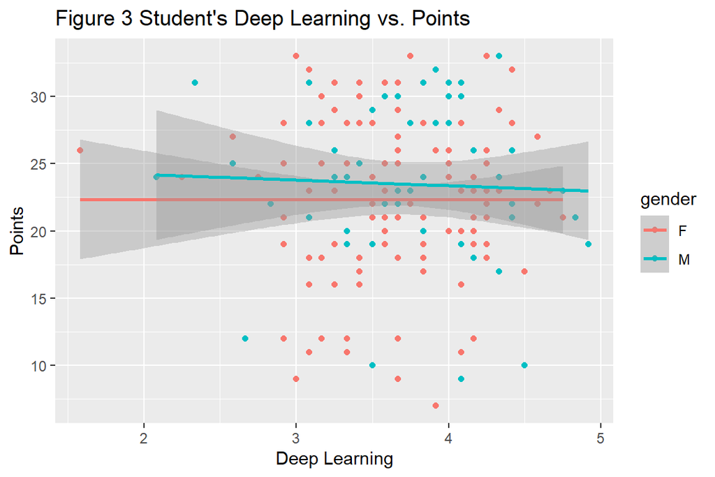

```r
plot_dp <- ggplot(l14, aes(x = deep, y = Points, col = gender)) + geom_point() + geom_smooth(method = "lm") + ggtitle("Figure 3 Student's Deep Learning vs. Points") + labs(x = "Deep Learning")
plot_dp
```

### 3.1.3 Surface Learning and Exam Points

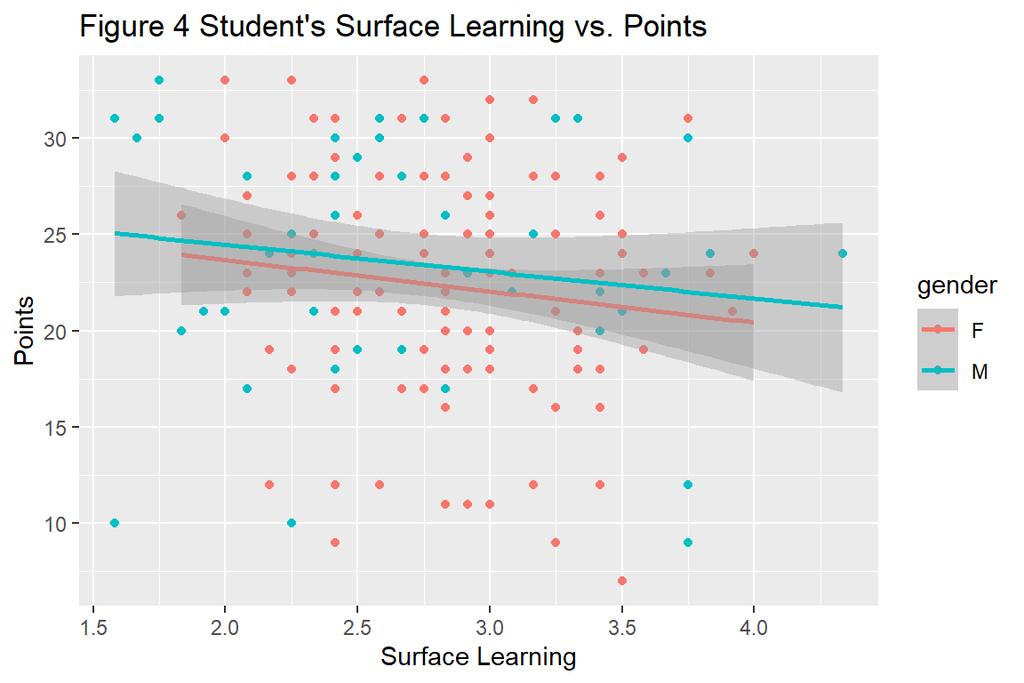

```r
plot_sp <- ggplot(l14, aes(x = surf, y = Points, col = gender)) + geom_point() + geom_smooth(method = "lm") + ggtitle("Figure 4 Student's Surface Learning vs. Points") + labs(x = "Surface Learning")
plot_sp
```

## 3.2 Multiple Regression

### 3.2.1 Overview of Variables

First, a quick graphic overview of the target variable (exam points) and explanatory variables (deep, surface, attitude) in a similar plot as in section 2. From this we can already deduce it may not make sense to perform a multiple regression analysis on the 3 variables because the surf and deep categories do not create a line of regression similar to attitude and points.  
A new dataset is created from the **l14** dataset selecting only the gender, attitude, surf, deep, and points variables. The dataset is plotted with the `plot` function and the first column (gender) omitted from the plot with `[-1]`.

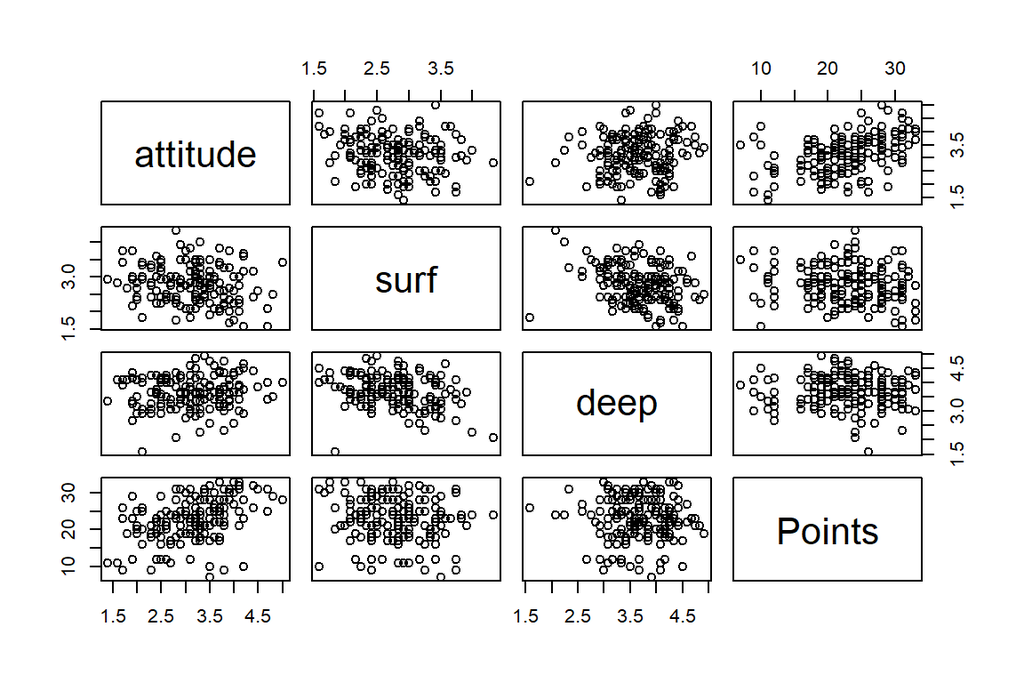

```r
l14_b <- select(l14, gender, attitude, surf, deep, Points)

plot(l14_b[-1])
```

### 3.2.2 Multiple Regression Model

For multiple regression, a formula is created with the `lm` linear model function that is assigned with the target value (Points) and the explanatory values (attitude + deep + surf). This means that points is predicted by attitude, deep learning, and surface learning. The formula is assigned as multiple_regression and a `summary` function produces the information below:

```r
multiple_regression <- lm(Points ~ attitude + deep + surf, data = l14)
mr <- summary(multiple_regression)
print(mr)
```

```
##
## Call:
## lm(formula = Points ~ attitude + deep + surf, data = l14)
##
## Residuals:
##      Min       1Q   Median       3Q      Max
## -16.9168  -3.1487   0.3667   3.8326  11.3519
##
## Coefficients:
##             Estimate Std. Error t value Pr(>|t|)
## (Intercept)  18.3551     4.7124   3.895 0.000143 ***
## attitude      3.4661     0.5766   6.011 1.18e-08 ***
## deep         -0.9485     0.7903  -1.200 0.231815
## surf         -1.0911     0.8360  -1.305 0.193669
## ---
## Signif. codes:  0 '***' 0.001 '**' 0.01 '*' 0.05 '.' 0.1 ' ' 1
##
## Residual standard error: 5.313 on 162 degrees of freedom
## Multiple R-squared:  0.2024, Adjusted R-squared:  0.1876
## F-statistic:  13.7 on 3 and 162 DF,  p-value: 5.217e-08
```

The multiple regression summary provides results for the validity of the model. The model’s adjusted R-Squared value is 0.1876, this is a fairly low score meaning that the three explanatory variables together account for only 19% of the variation.

The F-test for testing the hypothesis that all three regression coefficients are zero has a very low associated p-value. Thus there is strong evidence that not all three coefficients are zero.  
The Pr(>|t|) values for attitude, deep, and surf indicate that a) using attitude and deep would be better at predicting exam points and b) using attitude and surf would be better at predicting exam points. By changing the model to these two variants we can examine the validity of new models attitude + deep and attitude + surf:

```r
multiple_regression_ad <- lm(Points ~ attitude + deep, data = l14)
mrad <- summary(multiple_regression_ad)
multiple_regression_as <- lm(Points ~ attitude + surf, data = l14)
mras <- summary(multiple_regression_as)

print(mrad)
```

```
##
## Call:
## lm(formula = Points ~ attitude + deep, data = l14)
##
## Residuals:
##      Min       1Q   Median       3Q      Max
## -16.8463  -3.2975   0.2789   4.1213  11.1399
##
## Coefficients:
##             Estimate Std. Error t value Pr(>|t|)
## (Intercept)  13.7812     3.1574   4.365 2.25e-05 ***
## attitude      3.5780     0.5714   6.262 3.25e-09 ***
## deep         -0.6275     0.7526  -0.834    0.406
## ---
## Signif. codes:  0 '***' 0.001 '**' 0.01 '*' 0.05 '.' 0.1 ' ' 1
##
## Residual standard error: 5.325 on 163 degrees of freedom
## Multiple R-squared:  0.194,  Adjusted R-squared:  0.1841
## F-statistic: 19.62 on 2 and 163 DF,  p-value: 2.326e-08
```

For the model with attitude and deep learning the result is similar, attitude alone would be a better model.

```r
print(mras)
```

```
##
## Call:
## lm(formula = Points ~ attitude + surf, data = l14)
##
## Residuals:
##     Min      1Q  Median      3Q     Max
## -17.277  -3.236   0.386   3.977  10.642
##
## Coefficients:
##             Estimate Std. Error t value Pr(>|t|)
## (Intercept)  14.1196     3.1271   4.515 1.21e-05 ***
## attitude      3.4264     0.5764   5.944 1.63e-08 ***
## surf         -0.7790     0.7956  -0.979    0.329
## ---
## Signif. codes:  0 '***' 0.001 '**' 0.01 '*' 0.05 '.' 0.1 ' ' 1
##
## Residual standard error: 5.32 on 163 degrees of freedom
## Multiple R-squared:  0.1953, Adjusted R-squared:  0.1854
## F-statistic: 19.78 on 2 and 163 DF,  p-value: 2.041e-08
```

In the next section, the linear regression of exam points and attitude is examined by removing the deep and surface learning variables.

## 3.3 Model Changed to Simple Linear Regression

A similar formula is created as in the previous section. This time the formula is simple with points and attitude as the only values.

```r
regression <- lm(Points ~ attitude, data = l14)
summary(regression)
```

```
##
## Call:
## lm(formula = Points ~ attitude, data = l14)
##
## Residuals:
##      Min       1Q   Median       3Q      Max
## -16.9763  -3.2119   0.4339   4.1534  10.6645
##
## Coefficients:
##             Estimate Std. Error t value Pr(>|t|)
## (Intercept)  11.6372     1.8303   6.358 1.95e-09 ***
## attitude      3.5255     0.5674   6.214 4.12e-09 ***
## ---
## Signif. codes:  0 '***' 0.001 '**' 0.01 '*' 0.05 '.' 0.1 ' ' 1
##
## Residual standard error: 5.32 on 164 degrees of freedom
## Multiple R-squared:  0.1906, Adjusted R-squared:  0.1856
## F-statistic: 38.61 on 1 and 164 DF,  p-value: 4.119e-09
```

## 3.4 Diagnostic Plots

Diagnostic plots can be used to examine the violations in linear regression assumptions. Diagnostics plot can be made with `plot` function by assignin the linear model formula, created in section 3.3 as the data. The `which = c()` value selects the desired plots, in this case: Residuals vs Fitted, Normal Q-Q, and Residuals vs Leverage plots.

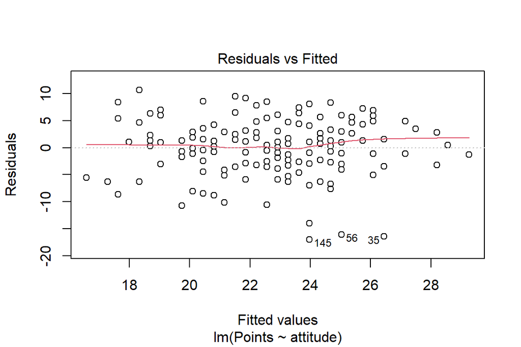

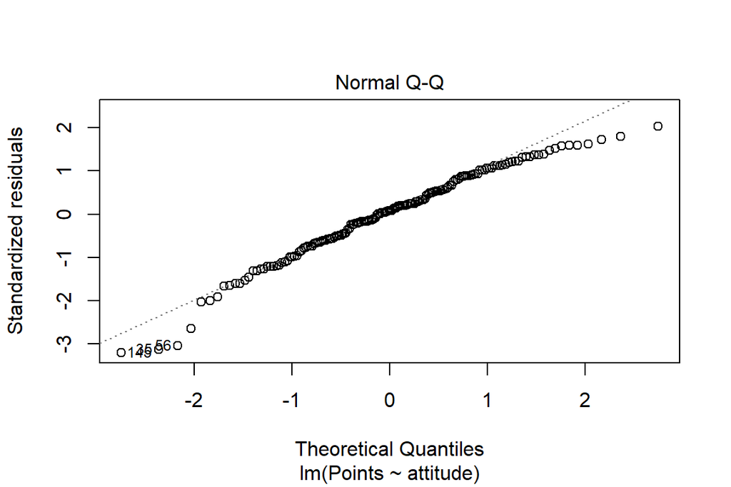

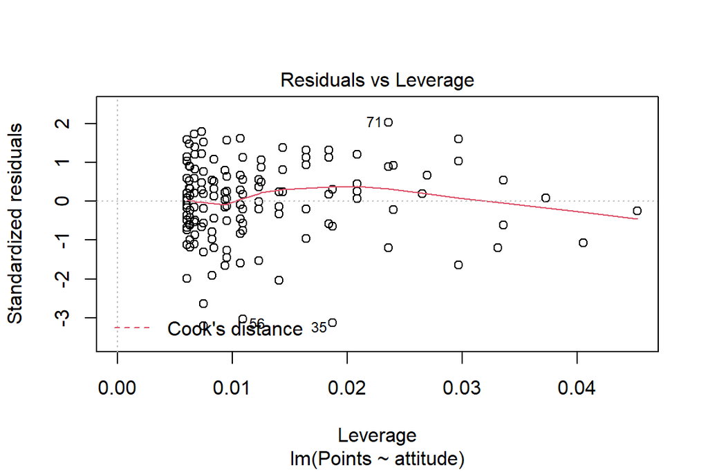

```r
dp <- plot(regression, which = c(1,2,5))
```

### 3.4.1 Residuals vs Fitted

The Residuals vs Fitted plot shows whether linearity holds. In addition, the spread of residuals should stay the same on the x-axis. In this plot the linearity holds reasonably well. There are however some outliers (145, 56, 35) that challenge assumptions of linearity.

### 3.4.2 Normal Q-Q

The Normal Q-Q plot provides a method to explore the normality assumption that errors are normally distributed. The Normal Q-Q plot shows that there is a reasonable fit in middle of the line but questionable in the beginning.

### 3.4.3 Residuals vs Leverage

Leverage measures a single observations impact on the model. Observations with unusually high impact can be found with the Residuals vs Leverage plot.

## 4 Conclusion

It always helps to have a positive attitude!

# Chapter 3 Logistic Regression

*This week I learned something about logistic regression and data wrangling to join datasets with common features. Again, the most frustrating part was trying to understand how to interpret statistics. There is still a lot to learn.*

## Library

```r
library(tidyverse)
```

## 1 Dataset and Description

### 1.1 Read Dataset from Local Directory

```r
alc <- read.csv("C:/Users/Jukke/OneDrive/Työpöytä/IODS/IODS-project/data/alc.csv")
```

### 1.2 Description

The original datasets used for this chapter are made by Paulo Cortez.  
Link to [metadata](https://archive.ics.uci.edu/ml/datasets/Student+Performance)  
**Database citation**:  
P. Cortez and A. Silva. Using Data Mining to Predict Secondary School Student Performance. In A. Brito and J. Teixeira Eds., Proceedings of 5th FUture BUsiness TEChnology Conference (FUBUTEC 2008) pp. 5-12, Porto, Portugal, April, 2008, EUROSIS, ISBN 978-9077381-39-7.  
**Original Dataset information**: Datasets of student achievement in secondary education in maths and Portuguese in two Portuguese schools with grades and social attributes. Original datasets contains 30 social attributes and 3 grade attributes (first period, second periond, and final grade).

### 1.3 Derived dataset

The dataset discussed in this report is derived from the original dataset, discussed in the previous section, by joining the math and Portuguese datasets. Observations with matching social attributes (same student) were selected from the datasets and their scores were averaged. Additional columns for alcohol use (alc_use) and high use (high_use) were created by averaging scores for weekday and weekend alcohol use, and high quantities thereof respectively.

```r
glimpse(alc)
```

```
## Rows: 382
## Columns: 35
## $ school     <chr> "GP", "GP", "GP", "GP", "GP", "GP", "GP", "GP", "GP", "G...
## $ sex        <chr> "F", "F", "F", "F", "F", "M", "M", "F", "M", "M", "F", "...
## $ age        <int> 18, 17, 15, 15, 16, 16, 16, 17, 15, 15, 15, 15, 15, 15, ...
## $ address    <chr> "U", "U", "U", "U", "U", "U", "U", "U", "U", "U", "U", "...
## $ famsize    <chr> "GT3", "GT3", "LE3", "GT3", "GT3", "LE3", "LE3", "GT3", ...
## $ Pstatus    <chr> "A", "T", "T", "T", "T", "T", "T", "A", "A", "T", "T", "...
## $ Medu       <int> 4, 1, 1, 4, 3, 4, 2, 4, 3, 3, 4, 2, 4, 4, 2, 4, 4, 3, 3,...
## $ Fedu       <int> 4, 1, 1, 2, 3, 3, 2, 4, 2, 4, 4, 1, 4, 3, 2, 4, 4, 3, 2,...
## $ Mjob       <chr> "at_home", "at_home", "at_home", "health", "other", "ser...
## $ Fjob       <chr> "teacher", "other", "other", "services", "other", "other...
## $ reason     <chr> "course", "course", "other", "home", "home", "reputation...
## $ nursery    <chr> "yes", "no", "yes", "yes", "yes", "yes", "yes", "yes", "...
## $ internet   <chr> "no", "yes", "yes", "yes", "no", "yes", "yes", "no", "ye...
```

[output cut: 22 more lines]

The dataset contains 382 observations (students) of 35 variables, see [metadata](https://archive.ics.uci.edu/ml/datasets/Student+Performance) for description. In addition, alc_use is `(Dalc + Walc) / 2` and high_use is logical TRUE/FALSE where `alc_use > 2`

## 2 Exploring Alcohol Use and Other Variables

The purpose of this chapter is to study the relation of high/low alchol use with other variables from the dataset.

### 2.3 Variables

I have chosen 4 variables of interest: sex, failures, famrel, and G3.  
**Sex**: Binary M/F  
*Hypothesis*: Sex will not correlate with use of alcohol  
**Failures**: Number of past class failures  
*Hypothesis*: Intuitively, failures might have correlations with alcohol use if alcohol use is an indicator of other social problems as well.  
**Famrel**: Quality of family relationships (numeric: from 1 - very bad to 5 - excellent)  
*Hypothesis*: Same as above, bad family relations might correlate with higher alcohol use.  
**G3**: Final Grade (average of math and Portuguese), numeric: from 0 to 20  
*Hypothesis*: Alcohol use and final grade may correlate.

### 2.3 Variable counts

There are 114 observations of High Alcohol Use, and 268 observations of non-high use:

```r
high_use <- alc %>% count(high_use)
high_use
```

```
##   high_use   n
## 1    FALSE 268
## 2     TRUE 114
```

#### 2.3.1 Sex and Alcohol Use

High use is distributed unequally between M (72/184)and F(42/198). First I check the possible values of sex with `distinct` to make sure nothing strange is in the dataset. I change the sex column into `factor` (not sure if necessary) check that it has worked with `str` and then proceed to `ggplot` with `geombar`. From this we see a differential distribution of alcohol use with regards to sex. This can also be seen in numbers with `xtabs`. A simple logistic regression with the generalised linear model `glm`, attributed with the argument `family = "binomial"`, which makes the function perform logistic regression, reveals a statistically significant relation with high alcohol use and sex in the dataset. The log(odds) for a female having high alcohol use (AU) is -1.3122 and the increase in log(odds) to a male having high AU is 0.8704. My intuitive hypothesis was wrong.

```r
distinct(alc, sex)
```

```
##   sex
## 1   F
## 2   M
```

```r
alc$sex <- as.factor(alc$sex)
str(alc)
```

```
## 'data.frame':    382 obs. of  35 variables:
##  $ school    : chr  "GP" "GP" "GP" "GP" ...
##  $ sex       : Factor w/ 2 levels "F","M": 1 1 1 1 1 2 2 1 2 2 ...
##  $ age       : int  18 17 15 15 16 16 16 17 15 15 ...
##  $ address   : chr  "U" "U" "U" "U" ...
##  $ famsize   : chr  "GT3" "GT3" "LE3" "GT3" ...
##  $ Pstatus   : chr  "A" "T" "T" "T" ...
##  $ Medu      : int  4 1 1 4 3 4 2 4 3 3 ...
##  $ Fedu      : int  4 1 1 2 3 3 2 4 2 4 ...
##  $ Mjob      : chr  "at_home" "at_home" "at_home" "health" ...
##  $ Fjob      : chr  "teacher" "other" "other" "services" ...
##  $ reason    : chr  "course" "course" "other" "home" ...
##  $ nursery   : chr  "yes" "no" "yes" "yes" ...
##  $ internet  : chr  "no" "yes" "yes" "yes" ...
##  $ guardian  : chr  "mother" "father" "mother" "mother" ...
```

[output cut: 21 more lines]

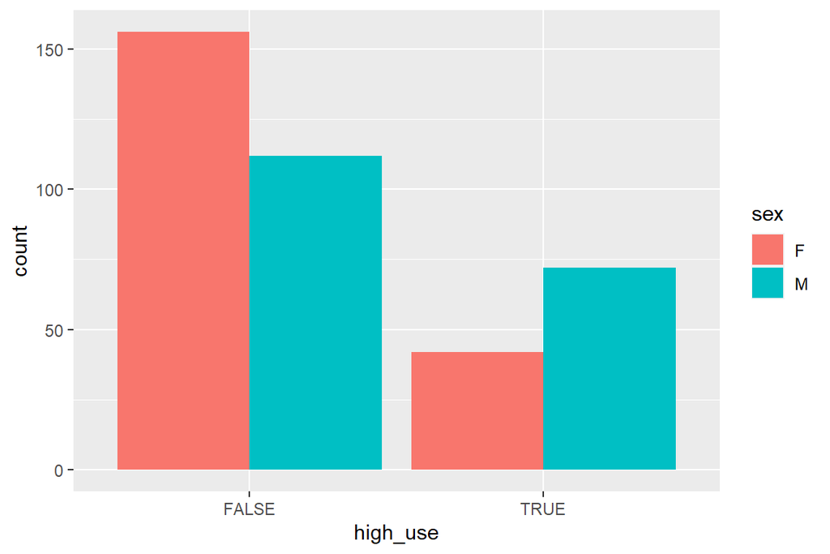

```r
pS <- ggplot(alc, aes(x = high_use, fill = sex))
pS + geom_bar(position = "dodge")
```

```r
xtabs(~ sex + high_use, data=alc)
```

```
##    high_use
## sex FALSE TRUE
##   F   156   42
##   M   112   72
```

```r
sexlog <- glm(high_use ~ sex, data = alc, family = "binomial")
summary(sexlog)
```

```
##
## Call:
## glm(formula = high_use ~ sex, family = "binomial", data = alc)
##
## Deviance Residuals:
##     Min       1Q   Median       3Q      Max
## -0.9964  -0.9964  -0.6905   1.3699   1.7610
##
## Coefficients:
##             Estimate Std. Error z value Pr(>|z|)
## (Intercept)  -1.3122     0.1738  -7.548 4.41e-14 ***
## sexM          0.8704     0.2303   3.779 0.000157 ***
## ---
## Signif. codes:  0 '***' 0.001 '**' 0.01 '*' 0.05 '.' 0.1 ' ' 1
##
## (Dispersion parameter for binomial family taken to be 1)
##
##     Null deviance: 465.68  on 381  degrees of freedom
## Residual deviance: 450.95  on 380  degrees of freedom
## AIC: 454.95
##
## Number of Fisher Scoring iterations: 4
```

#### 2.3.2 Final Grade and Alcohol Use

By plotting high_use with G3 we can get a graphic overview of high alcohol use and final grade. Here I use the `geom_boxplot` to visualise the results.

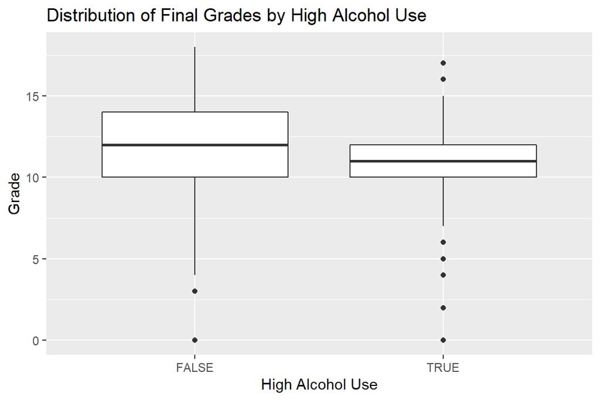

```r
pG3 <- ggplot(alc, aes(x = high_use, y = G3))
pG3 + geom_boxplot() + ggtitle("Distribution of Final Grades by High Alcohol Use") + labs(y = "Grade", x = "High Alcohol Use")
```

```r
G3log <- glm(high_use ~ G3, data = alc, family = "binomial")
summary(G3log)
```

```
##
## Call:
## glm(formula = high_use ~ G3, family = "binomial", data = alc)
##
## Deviance Residuals:
##     Min       1Q   Median       3Q      Max
## -1.2184  -0.8504  -0.7634   1.4307   1.7720
##
## Coefficients:
##             Estimate Std. Error z value Pr(>|z|)
## (Intercept)  0.09597    0.39319   0.244   0.8072
## G3          -0.08428    0.03389  -2.487   0.0129 *
## ---
## Signif. codes:  0 '***' 0.001 '**' 0.01 '*' 0.05 '.' 0.1 ' ' 1
##
## (Dispersion parameter for binomial family taken to be 1)
##
##     Null deviance: 465.68  on 381  degrees of freedom
## Residual deviance: 459.43  on 380  degrees of freedom
## AIC: 463.43
##
## Number of Fisher Scoring iterations: 4
```

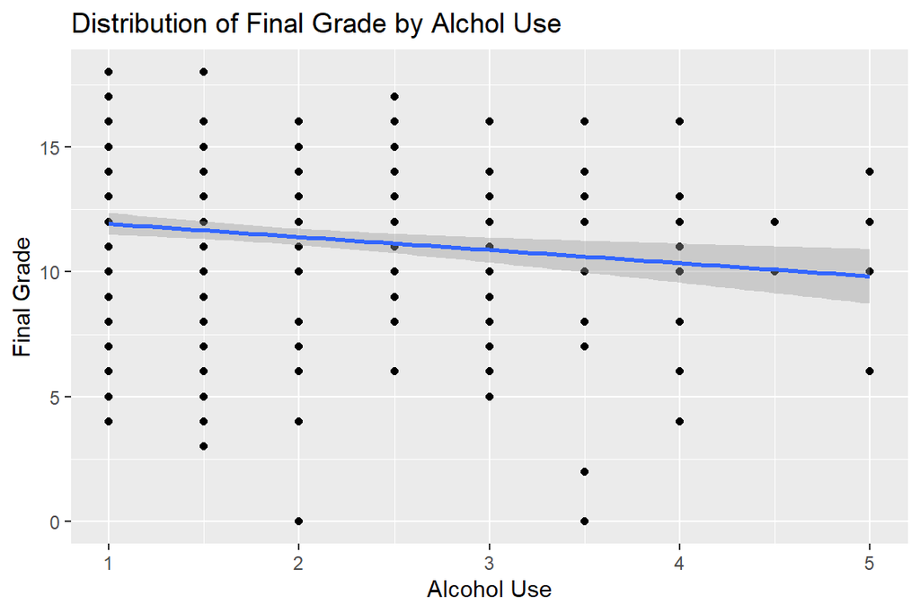

```r
pG3b <- ggplot(alc, aes(x = alc_use, y = G3))
pG3b + geom_point() + geom_smooth(method = "lm") + ggtitle("Distribution of Final Grade by Alchol Use") + labs(x = "Alcohol Use", y = "Final Grade")
```

#### 2.3.3 Family Relations and Alcohol Use

Make the same boxplot and `glm` for family relations:

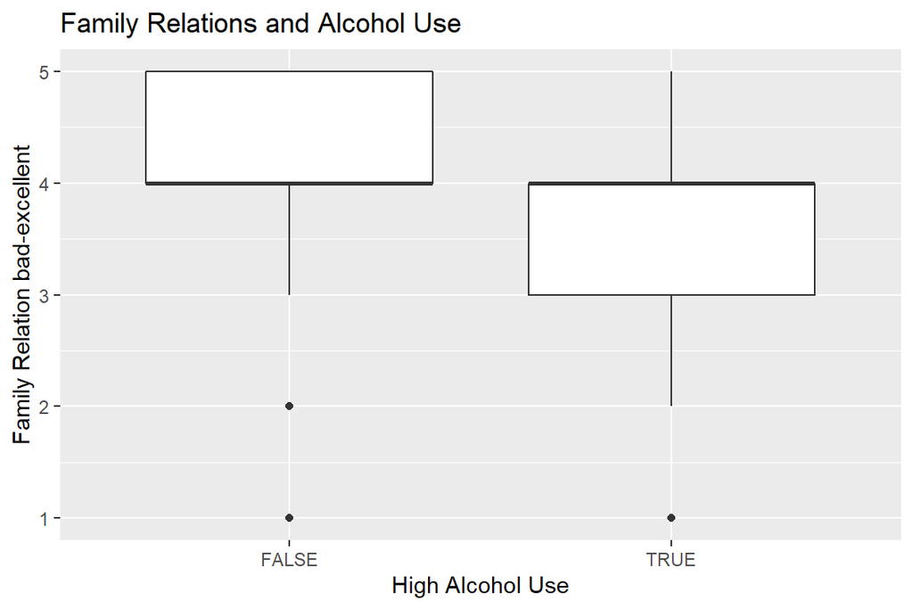

```r
pFR <- ggplot(alc, aes(x = high_use, y = famrel))
pFR + geom_boxplot() + ggtitle("Family Relations and Alcohol Use") + labs(y = "Family Relation bad-excellent", x = "High Alcohol Use")
```

```r
famlog <- glm(high_use ~ famrel, data = alc, family = "binomial")
summary(famlog)
```

```
##
## Call:
## glm(formula = high_use ~ famrel, family = "binomial", data = alc)
##
## Deviance Residuals:
##     Min       1Q   Median       3Q      Max
## -1.1404  -0.8323  -0.7427   1.4483   1.6869
##
## Coefficients:
##             Estimate Std. Error z value Pr(>|z|)
## (Intercept)   0.1772     0.4812   0.368   0.7127
## famrel       -0.2649     0.1212  -2.185   0.0289 *
## ---
## Signif. codes:  0 '***' 0.001 '**' 0.01 '*' 0.05 '.' 0.1 ' ' 1
##
## (Dispersion parameter for binomial family taken to be 1)
##
##     Null deviance: 465.68  on 381  degrees of freedom
## Residual deviance: 460.92  on 380  degrees of freedom
## AIC: 464.92
##
## Number of Fisher Scoring iterations: 4
```

The boxplot shows that High Alcohol Users have reported worse family relations and the `summary` for the glm shows statistical significance.

#### 2.3.4 Failures and Alcohol Use

This boxplot reveals that it was a silly idea to try to boxplot failures. A look at the count does reveal there might be something of interest, as the counts for failures are similar for non-high and high AU despite non-high AU outnumbering the high AU.

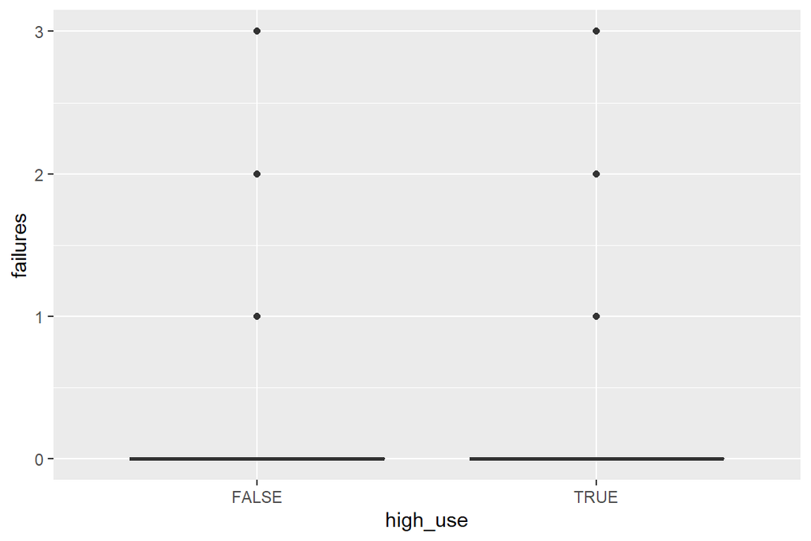

```r
pF <- ggplot(alc, aes(x = high_use, y = failures))
pF + geom_boxplot()
```

```r
silly <- alc %>% group_by(failures, high_use) %>% count()
silly
```

```
## # A tibble: 8 x 3
## # Groups:   failures, high_use [8]
##   failures high_use     n
##      <int> <lgl>    <int>
## 1        0 FALSE      244
## 2        0 TRUE        90
## 3        1 FALSE       12
## 4        1 TRUE        12
## 5        2 FALSE       10
## 6        2 TRUE         9
## 7        3 FALSE        2
## 8        3 TRUE         3
```

```r
failog <- glm(high_use ~ failures, data = alc, family = "binomial")
summary(failog)
```

```
##
## Call:
## glm(formula = high_use ~ failures, family = "binomial", data = alc)
##
## Deviance Residuals:
##     Min       1Q   Median       3Q      Max
## -1.4506  -0.7998  -0.7998   1.3703   1.6097
##
## Coefficients:
##             Estimate Std. Error z value Pr(>|z|)
## (Intercept)  -0.9756     0.1212   -8.05 8.28e-16 ***
## failures      0.5327     0.1812    2.94  0.00328 **
## ---
## Signif. codes:  0 '***' 0.001 '**' 0.01 '*' 0.05 '.' 0.1 ' ' 1
##
## (Dispersion parameter for binomial family taken to be 1)
##
##     Null deviance: 465.68  on 381  degrees of freedom
## Residual deviance: 456.98  on 380  degrees of freedom
## AIC: 460.98
##
## Number of Fisher Scoring iterations: 4
```

**Let’s try something else**. I change the failures column to a factor between student’s who have not failed (No) and students who have failed (Yes). This is done with the `ifelse` function that tests if the integer in numbers is 0, if yes then the student has not failed `yes = "No"` and vice versa. I tried to be funny at first and use “Nailed It” vs. “Failed It” but it looked ugly in the `summary`!

```r
alc$failures <- ifelse(test = alc$failures == 0, yes = "No", no = "Yes")
alc$failures <- as.factor(alc$failures)

xtabs(~ failures + high_use, data = alc)
```

```
##         high_use
## failures FALSE TRUE
##      No    244   90
##      Yes    24   24
```

```r
failog <- glm(high_use ~ failures, data = alc, family = "binomial")
summary(failog)
```

```
##
## Call:
## glm(formula = high_use ~ failures, family = "binomial", data = alc)
##
## Deviance Residuals:
##     Min       1Q   Median       3Q      Max
## -1.1774  -0.7924  -0.7924   1.1774   1.6195
##
## Coefficients:
##             Estimate Std. Error z value Pr(>|z|)
## (Intercept)  -0.9974     0.1233  -8.087 6.11e-16 ***
## failuresYes   0.9974     0.3139   3.177  0.00149 **
## ---
## Signif. codes:  0 '***' 0.001 '**' 0.01 '*' 0.05 '.' 0.1 ' ' 1
##
## (Dispersion parameter for binomial family taken to be 1)
##
##     Null deviance: 465.68  on 381  degrees of freedom
## Residual deviance: 455.80  on 380  degrees of freedom
## AIC: 459.8
##
## Number of Fisher Scoring iterations: 4
```

From this we see in the `xtabs` that the odds for failing when high_use is TRUE is higher. We also get a slightly better result (do we?) for the `glm` `summary`.

## 3 Logistic Regression

In this section I make a `glm` model of `high_use` predicted by `failures` (Yes/No),`G3` `famrel`, and `sex`.

```r
m <- glm(high_use ~ failures + G3 + famrel + sex, data = alc, family = "binomial")


summary(m)
```

```
##
## Call:
## glm(formula = high_use ~ failures + G3 + famrel + sex, family = "binomial",
##     data = alc)
##
## Deviance Residuals:
##     Min       1Q   Median       3Q      Max
## -1.5508  -0.8521  -0.6323   1.2056   2.0863
##
## Coefficients:
##             Estimate Std. Error z value Pr(>|z|)
## (Intercept)  0.25806    0.67429   0.383 0.701929
## failuresYes  0.72633    0.35352   2.055 0.039922 *
## G3          -0.05299    0.03816  -1.389 0.164947
## famrel      -0.28260    0.12637  -2.236 0.025337 *
## sexM         0.92053    0.23750   3.876 0.000106 ***
## ---
## Signif. codes:  0 '***' 0.001 '**' 0.01 '*' 0.05 '.' 0.1 ' ' 1
##
## (Dispersion parameter for binomial family taken to be 1)
##
##     Null deviance: 465.68  on 381  degrees of freedom
## Residual deviance: 434.75  on 377  degrees of freedom
## AIC: 444.75
##
## Number of Fisher Scoring iterations: 4
```

Out of the four variables used to predict high AU, the final grade G3 conditional on the other explanatory variables performs the worst in the model and the low z value and high p-value suggest it is better to leave it out of the model, which is done in section 3.2.

### 3.1 Odds Ratio and Confidence Interval

To get odds ratios we can apply the exponent function `exp` to the coefficients of the model and assign the output as `OR`. For confidence intervals use the `exp` and `confint` functions on the model.

```r
OR <- coef(m) %>% exp

CI <- confint(m) %>% exp
cbind(OR, CI)
```

```
##                    OR     2.5 %    97.5 %
## (Intercept) 1.2944226 0.3434018 4.8737594
## failuresYes 2.0674839 1.0298765 4.1416381
## G3          0.9483869 0.8794608 1.0217987
## famrel      0.7538209 0.5873863 0.9658242
## sexM        2.5106222 1.5841230 4.0260443
```

What these mean. The exponents of the coefficients can be interpreted as odd ratios (**OR**) for High AU between a unit change (vs no change) in the explanatory variable. The CI output is showing several 95% intervals. It is two-tailed, from the 2.5% point to the 97.5% point of the relevant distribution. These form the upper and lower limits of the intervals. The factor variables sex and failures show width in their distribution.

### 3.2 New Model

For a new model I repeat the steps in the previous section, but omit G3 as an explanatory variable.

```r
m1 <- glm(high_use ~ failures + sex + famrel, data = alc, family = "binomial")

summary(m1)
```

```
##
## Call:
## glm(formula = high_use ~ failures + sex + famrel, family = "binomial",
##     data = alc)
##
## Deviance Residuals:
##     Min       1Q   Median       3Q      Max
## -1.5802  -0.8370  -0.6357   1.1834   1.9682
##
## Coefficients:
##             Estimate Std. Error z value Pr(>|z|)
## (Intercept)  -0.3570     0.5085  -0.702 0.482576
## failuresYes   0.9247     0.3233   2.860 0.004234 **
## sexM          0.9125     0.2368   3.854 0.000116 ***
## famrel       -0.2848     0.1260  -2.260 0.023829 *
## ---
## Signif. codes:  0 '***' 0.001 '**' 0.01 '*' 0.05 '.' 0.1 ' ' 1
##
## (Dispersion parameter for binomial family taken to be 1)
##
##     Null deviance: 465.68  on 381  degrees of freedom
## Residual deviance: 436.69  on 378  degrees of freedom
## AIC: 444.69
##
## Number of Fisher Scoring iterations: 4
```

```r
OR1 <- coef(m1) %>% exp


CI1 <- confint(m1) %>% exp
cbind(OR1, CI1)
```

```
##                   OR1     2.5 %    97.5 %
## (Intercept) 0.6997429 0.2549556 1.8868349
## failuresYes 2.5210180 1.3345773 4.7672023
## sexM        2.4905835 1.5736004 3.9879379
## famrel      0.7521293 0.5863812 0.9629022
```

```r
########################
# anova(m, m1, test ="LRT")
########################
```

The model performs better, but there is a low difference in the Null Deviance and Residual Deviance. This spells trouble. A look at how the model predicts reveals some of its problems in the next section.

### 3.3 Prediction

For prediction based on the model we need to create a value for probabilities with the `predict` function used on the m1 model. A column is created for probability that contains the values of the probabilities created. A second new column is created for probabilities over 0.5, which estimates the high alcohol use to be TRUE.

```r
# predict() the probability of high_use
probabilities <- predict(m1, type = "response")

# add the predicted probabilities to 'alc'
alc <- mutate(alc, probability = probabilities)

# use the probabilities to make a prediction of high_use
alc <- mutate(alc, prediction = probability > 0.5)

# tabulate the target variable versus the predictions
table(high_use = alc$high_use, prediction = alc$prediction)
```

```
##         prediction
## high_use FALSE TRUE
##    FALSE   255   13
##    TRUE     97   17
```

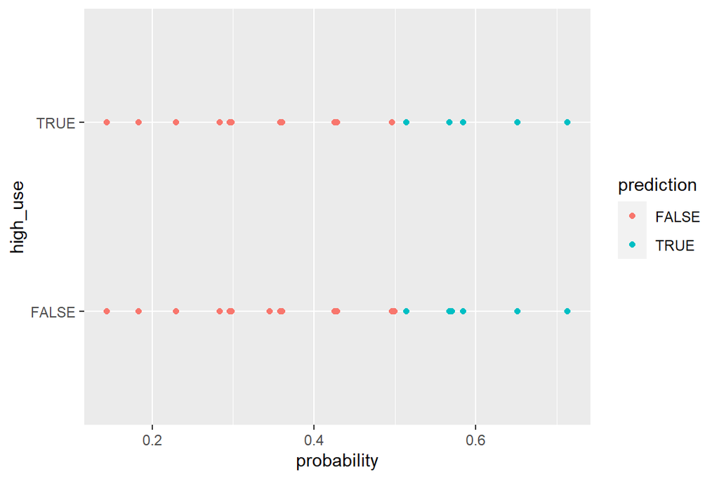

```r
g <- ggplot(alc, aes(x = probability, y = high_use, col = prediction))

# define the geom as points and draw the plot
g + geom_point()
```

```r
table(high_use = alc$high_use, prediction = alc$prediction) %>% prop.table %>% addmargins
```

```
##         prediction
## high_use      FALSE       TRUE        Sum
##    FALSE 0.66753927 0.03403141 0.70157068
##    TRUE  0.25392670 0.04450262 0.29842932
##    Sum   0.92146597 0.07853403 1.00000000
```

```r
alc <- alc %>% mutate(TEST = case_when(
  high_use == FALSE & prediction == FALSE ~ "YAY",
  high_use == TRUE & prediction == TRUE ~ "SWEET",
  high_use == FALSE & prediction == TRUE ~ "NAY",
  high_use == TRUE & prediction == FALSE ~ "DAMN"))

test_count <- alc %>% count(TEST)
print(test_count)
```

```
##    TEST   n
## 1  DAMN  97
## 2   NAY  13
## 3 SWEET  17
## 4   YAY 255
```

### 3.4 Prediction Error

Prediction error for the new model can be tested by creating a new function, though I do not entirely understand what is happening in it. The function contains two arguments class and prob on which it counts the mean of n_wrong. n_wrong is defined as `abs(class - prob) > 0.5` but what exactly that means is a mystery to me.

```r
# define a loss function (average prediction error)
loss_func <- function(class, prob) {
  n_wrong <- abs(class - prob) > 0.5
  mean(n_wrong)
}

# call loss_func to compute the average number of wrong predictions in the (training) data
loss_func(class = alc$high_use, prob = alc$probability)
```

```
## [1] 0.2879581
```

The output gives the average number of wrong predictions as 0.29. While it may seem kind of decent, we have to remember how miserably the prediction worked for predicting TRUE High Use. So if we wanted to use this model for something, it would be okay at predicting non-high alcohol use (and as such, it could create a “risk group” for high alcohol use) but ultimately it is insufficient in predicting High Alcohol Use.